# Consumer Data - Exploratory Data Analysis

Brett Moxham

26/09/2020

```r
library(tidyverse)
library(lubridate) #used to parse date and time in our data cleaning step.
library(gt)
```

# Objective

**Taking the data set provided by the [UCI Machine Learning Repository](https://archive.ics.uci.edu/ml/datasets/online+retail#), we want to take an exploratory data analysis approach to gain insights into this store’s customer.** This data set contains transactions occurring between 01/12/2010 and 09/12/2011 for a UK-based and registered non-store online retail.The company mainly sells unique all-occasion gifts. Many customers of the company are wholesalers.

A few things that we want to look at:

- Sales by day
- Unit drivers
- Dollar drivers
- Orders/order value by country

# Data

As stated above, we’ve taken data provided from the UCI Machine Learning Repository. You can find a link to the actual data [here](https://archive.ics.uci.edu/ml/machine-learning-databases/00352/).

```r
online_retail <-  readxl::read_xlsx("Online Retail.xlsx") ##reads in our data

online_retail <- online_retail %>% ##converts character variables to factor
  mutate_if(is.character, as.factor) %>%
  janitor::clean_names() ## cleans up variable names.
```

## Data Cleaning

Let’s take a quick first look at our data so we can see what we are dealing with.

```r
skimr::skim(online_retail)
```

Data summary

| Name | online_retail |
| --- | --- |
| Number of rows | 541909 |
| Number of columns | 8 |
| _______________________ |  |
| Column type frequency: |  |
| factor | 4 |
| numeric | 3 |
| POSIXct | 1 |
| ________________________ |  |
| Group variables | None |

**Variable type: factor**

| skim_variable | n_missing | complete_rate | ordered | n_unique | top_counts |
| --- | --- | --- | --- | --- | --- |
| invoice_no | 0 | 1 | FALSE | 25900 | 573: 1114, 581: 749, 581: 731, 580: 721 |
| stock_code | 0 | 1 | FALSE | 4070 | 851: 2313, 224: 2203, 850: 2159, 475: 1727 |
| description | 1454 | 1 | FALSE | 4211 | WHI: 2369, REG: 2200, JUM: 2159, PAR: 1727 |
| country | 0 | 1 | FALSE | 38 | Uni: 495478, Ger: 9495, Fra: 8557, EIR: 8196 |

**Variable type: numeric**

| skim_variable | n_missing | complete_rate | mean | sd | p0 | p25 | p50 | p75 | p100 | hist |
| --- | --- | --- | --- | --- | --- | --- | --- | --- | --- | --- |
| quantity | 0 | 1.00 | 9.55 | 218.08 | -80995.00 | 1.00 | 3.00 | 10.00 | 80995 | ▁▁▇▁▁ |
| unit_price | 0 | 1.00 | 4.61 | 96.76 | -11062.06 | 1.25 | 2.08 | 4.13 | 38970 | ▁▇▁▁▁ |
| customer_id | 135080 | 0.75 | 15287.69 | 1713.60 | 12346.00 | 13953.00 | 15152.00 | 16791.00 | 18287 | ▇▇▇▇▇ |

**Variable type: POSIXct**

| skim_variable | n_missing | complete_rate | min | max | median | n_unique |
| --- | --- | --- | --- | --- | --- | --- |
| invoice_date | 0 | 1 | 2010-12-01 08:26:00 | 2011-12-09 12:50:00 | 2011-07-19 17:17:00 | 23260 |

- The invoice number
- The stock code
- The stock description
- Country of purchase
- Quantity purchased
- Unit price
- Anonymized customer ID number
- Invoice date

Most of our data points are fully complete. However we are missing some item descriptions, quite a few (25%) of our customer ID’s. These two are not able to be imputed, and we can chalk up to data quality issues. There isn’t much that we can do to remedy this. Notice too, that we don’t have a total value of individual purchases, or a total dollar value of each invoice. These are important factors to consider. We can pretty simply create these variables. Let’s also add in some date variables that we may want to look at. Finally, when we look at our `quantity` tab, we see that the lowest value is -80995. Without being to verify, we must assume that this means that stock was returned to the store. It could be a data quality issue, but we have no way of knowing.

Now that we have looked at our data, it is time to add in some extra variables that will help in our analysis. We will create a new data frame and call it `sales`.

```r
sales <- online_retail %>%
  mutate(item_value = unit_price*quantity) %>%
  group_by(invoice_no) %>%
  mutate(invoice_total_value = sum(item_value)) %>%
  ungroup() %>%
  mutate(date = date(invoice_date), #adds in the full date, strips time
         month = month(invoice_date), ## adds invoice month
         day = day(invoice_date), ## adds invoice day in month (1-31)
         weekday = wday(invoice_date), ## adds invoice weekday (1-7) need to find if they start week on monday or sunday
         hour = hour(invoice_date)) %>%  ## adds invoice hour
    ungroup() %>%
    filter(!str_detect(description, "^[:lower:]+$"))## Found a bunch of item descriptions that seemed to be one off descriptions like "damaged", "broken" etc.. This function removes those from the data set.

skimr::skim(sales)
```

Data summary

| Name | sales |
| --- | --- |
| Number of rows | 540118 |
| Number of columns | 15 |
| _______________________ |  |
| Column type frequency: |  |
| Date | 1 |
| factor | 4 |
| numeric | 9 |
| POSIXct | 1 |
| ________________________ |  |
| Group variables | None |

**Variable type: Date**

| skim_variable | n_missing | complete_rate | min | max | median | n_unique |
| --- | --- | --- | --- | --- | --- | --- |
| date | 0 | 1 | 2010-12-01 | 2011-12-09 | 2011-07-20 | 305 |

**Variable type: factor**

| skim_variable | n_missing | complete_rate | ordered | n_unique | top_counts |
| --- | --- | --- | --- | --- | --- |
| invoice_no | 0 | 1 | FALSE | 24109 | 573: 1114, 581: 749, 581: 731, 580: 721 |
| stock_code | 0 | 1 | FALSE | 3954 | 851: 2313, 224: 2200, 850: 2159, 475: 1727 |
| description | 0 | 1 | FALSE | 4186 | WHI: 2369, REG: 2200, JUM: 2159, PAR: 1727 |
| country | 0 | 1 | FALSE | 38 | Uni: 493687, Ger: 9495, Fra: 8557, EIR: 8196 |

**Variable type: numeric**

| skim_variable | n_missing | complete_rate | mean | sd | p0 | p25 | p50 | p75 | p100 | hist |
| --- | --- | --- | --- | --- | --- | --- | --- | --- | --- | --- |
| quantity | 0 | 1.00 | 9.64 | 218.00 | -80995.00 | 1.00 | 3.00 | 10.00 | 80995.0 | ▁▁▇▁▁ |
| unit_price | 0 | 1.00 | 4.63 | 96.92 | -11062.06 | 1.25 | 2.08 | 4.13 | 38970.0 | ▁▇▁▁▁ |
| customer_id | 133289 | 0.75 | 15287.69 | 1713.60 | 12346.00 | 13953.00 | 15152.00 | 16791.00 | 18287.0 | ▇▇▇▇▇ |
| item_value | 0 | 1.00 | 18.05 | 379.44 | -168469.60 | 3.48 | 9.84 | 17.40 | 168469.6 | ▁▁▇▁▁ |
| invoice_total_value | 0 | 1.00 | 1343.76 | 2372.20 | -168469.60 | 288.99 | 517.05 | 1436.93 | 168469.6 | ▁▁▇▁▁ |
| month | 0 | 1.00 | 7.56 | 3.51 | 1.00 | 5.00 | 8.00 | 11.00 | 12.0 | ▃▂▃▃▇ |
| day | 0 | 1.00 | 15.02 | 8.66 | 1.00 | 7.00 | 15.00 | 22.00 | 31.0 | ▇▆▆▆▅ |
| weekday | 0 | 1.00 | 3.60 | 1.61 | 1.00 | 2.00 | 4.00 | 5.00 | 6.0 | ▇▅▅▅▅ |
| hour | 0 | 1.00 | 13.08 | 2.44 | 6.00 | 11.00 | 13.00 | 15.00 | 20.0 | ▁▅▇▆▁ |

**Variable type: POSIXct**

| skim_variable | n_missing | complete_rate | min | max | median | n_unique |
| --- | --- | --- | --- | --- | --- | --- |
| invoice_date | 0 | 1 | 2010-12-01 08:26:00 | 2011-12-09 12:50:00 | 2011-07-20 11:22:00 | 22050 |

Looking at our new data frame, we have a lot more data to work with. We can now organize our data in so many different ways, such as hour of day, or day of the week. Speaking of day of the week, It looks like we only have sales day for day 6. Meaning that sales are not processed one day out of the week. We need to know whether Sunday or Monday equates to day 1 of 7.

```r
sales %>%
  filter(date == "2010-12-01") %>%
  select(date, weekday)
```

```
## # A tibble: 3,098 x 2
##    date       weekday
##    <date>       <dbl>
##  1 2010-12-01       4
##  2 2010-12-01       4
##  3 2010-12-01       4
##  4 2010-12-01       4
##  5 2010-12-01       4
##  6 2010-12-01       4
##  7 2010-12-01       4
##  8 2010-12-01       4
##  9 2010-12-01       4
## 10 2010-12-01       4
## # ... with 3,088 more rows
```

Going back in the calendar, we know that December 1st 2020, starts on a Wednesday. This means that our week starts on Sunday, and by extension, that our store does not process sales on Saturday.

With our data in a more usable format, and some extra variables added, we can start our exploratory data analysis.

# Exploratory Data Analysis

## Sales Over Time

First and foremost, let’s look at the sales over the year. Let’s see if anything stands out right off the top before we get into the nitty gritty.

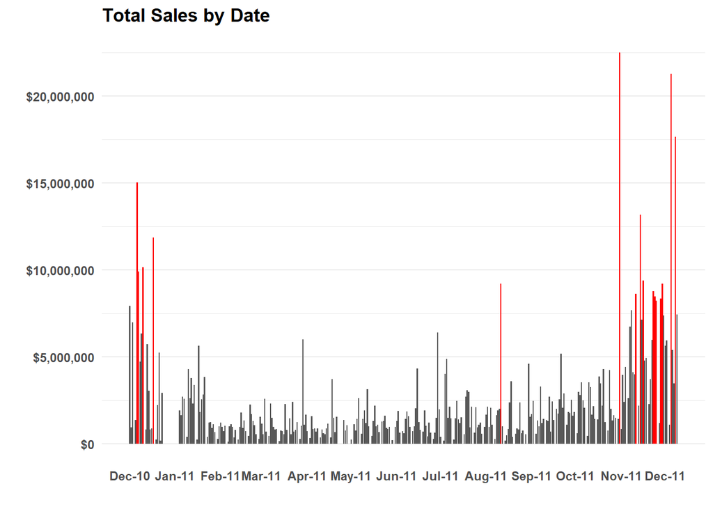

```r
sales %>%
  group_by(date) %>%
  summarise(total = sum(invoice_total_value)) %>%
  mutate(flag = ifelse(total >= 8000000, T, F)) %>%
  ggplot(aes(date, total)) +
  geom_col(aes(fill = flag)) +
  scale_y_continuous(labels = scales::dollar_format()) +
  scale_fill_manual(values = c('#595959', 'red'))+
  scale_x_date(date_breaks = "months" , date_labels = "%b-%y")+
  theme_minimal()+
  theme(text = element_text(family = "Nunito Bold", face = "bold"),
    legend.position = "none",
    panel.grid.major.x  = element_blank(),
    panel.grid.minor.x = element_blank()
  )+
  labs(
    title = "Total Sales by Date",
    x = "",
    y = ""
  )
```

```r
sales %>%
  filter(month == 8) %>%
  group_by(date) %>%
  summarise(total = sum(invoice_total_value)) %>%
  filter(total >= 8000000)
```

```
## # A tibble: 1 x 2
##   date          total
##   <date>        <dbl>
## 1 2011-08-11 9209482.
```

August 11th, 2011 had a total sales of 9.2 million. Let’s dive in and see if any orders stand out.

```r
sales %>%
  filter(date == "2011-08-11") %>%
  group_by(invoice_no) %>%
  summarize(total = sum(invoice_total_value)) %>%
  arrange(-total) %>%
  head(20) %>%
  knitr::kable()
```

| invoice_no | total |
| --- | --- |
| 562955 | 5887072.78 |
| 563076 | 2278928.54 |
| 563074 | 205693.84 |
| 563093 | 200606.56 |
| 562980 | 130418.40 |
| 563016 | 34799.80 |
| 562949 | 32643.02 |
| 563094 | 28079.52 |
| 562984 | 24586.05 |
| 562939 | 23787.36 |
| 562965 | 22004.40 |
| 563022 | 21986.85 |
| 562964 | 19270.80 |
| 563061 | 16496.20 |
| 563023 | 16030.20 |
| 563017 | 15675.52 |
| 563020 | 14523.36 |
| 563019 | 14297.28 |
| 563037 | 14077.50 |
| 563012 | 13375.53 |

We’ve got two invoices well over $200,000. Let’s examine those a little bit.

```r
sales %>%
  filter(invoice_no == 562955) %>%
  head(5) %>%
  select(-c(invoice_date, day, month, weekday, hour)) %>%
  knitr::kable()
```

| invoice_no | stock_code | description | quantity | unit_price | customer_id | country | item_value | invoice_total_value | date |
| --- | --- | --- | --- | --- | --- | --- | --- | --- | --- |
| 562955 | 22469 | HEART OF WICKER SMALL | 4 | 4.13 | NA | United Kingdom | 16.52 | 16677.26 | 2011-08-11 |
| 562955 | 22470 | HEART OF WICKER LARGE | 4 | 5.79 | NA | United Kingdom | 23.16 | 16677.26 | 2011-08-11 |
| 562955 | 22485 | SET OF 2 WOODEN MARKET CRATES | 3 | 24.96 | NA | United Kingdom | 74.88 | 16677.26 | 2011-08-11 |
| 562955 | 22488 | NATURAL SLATE RECTANGLE CHALKBOARD | 9 | 3.29 | NA | United Kingdom | 29.61 | 16677.26 | 2011-08-11 |
| 562955 | 22501 | PICNIC BASKET WICKER LARGE | 15 | 20.79 | NA | United Kingdom | 311.85 | 16677.26 | 2011-08-11 |

Well this first order, we don’t have a customer ID. It would be worth while to find who created this invoice, so we can execute targeted marketing for future repurchases!

```r
sales %>%
  filter(invoice_no == 563076) %>%
  head(5) %>%
  select(-c(invoice_date, day, month, weekday, hour)) %>%
  knitr::kable()
```

| invoice_no | stock_code | description | quantity | unit_price | customer_id | country | item_value | invoice_total_value | date |
| --- | --- | --- | --- | --- | --- | --- | --- | --- | --- |
| 563076 | 22795 | SWEETHEART RECIPE BOOK STAND | 16 | 5.95 | 14646 | Netherlands | 95.20 | 19150.66 | 2011-08-11 |
| 563076 | 23176 | ABC TREASURE BOOK BOX | 72 | 1.95 | 14646 | Netherlands | 140.40 | 19150.66 | 2011-08-11 |
| 563076 | 22399 | MAGNETS PACK OF 4 CHILDHOOD MEMORY | 108 | 1.06 | 14646 | Netherlands | 114.48 | 19150.66 | 2011-08-11 |
| 563076 | 23268 | SET OF 2 CERAMIC CHRISTMAS REINDEER | 384 | 1.25 | 14646 | Netherlands | 480.00 | 19150.66 | 2011-08-11 |
| 563076 | 23270 | SET OF 2 CERAMIC PAINTED HEARTS | 192 | 1.25 | 14646 | Netherlands | 240.00 | 19150.66 | 2011-08-11 |

This is a big order out of the Netherlands that we do actually have a customer ID for. When we do our analysis on where our buying comes from, we should pay attention to the Netherlands. Perhaps this one buyer makes up a large portion of that countries total buying.

## Unit Drivers

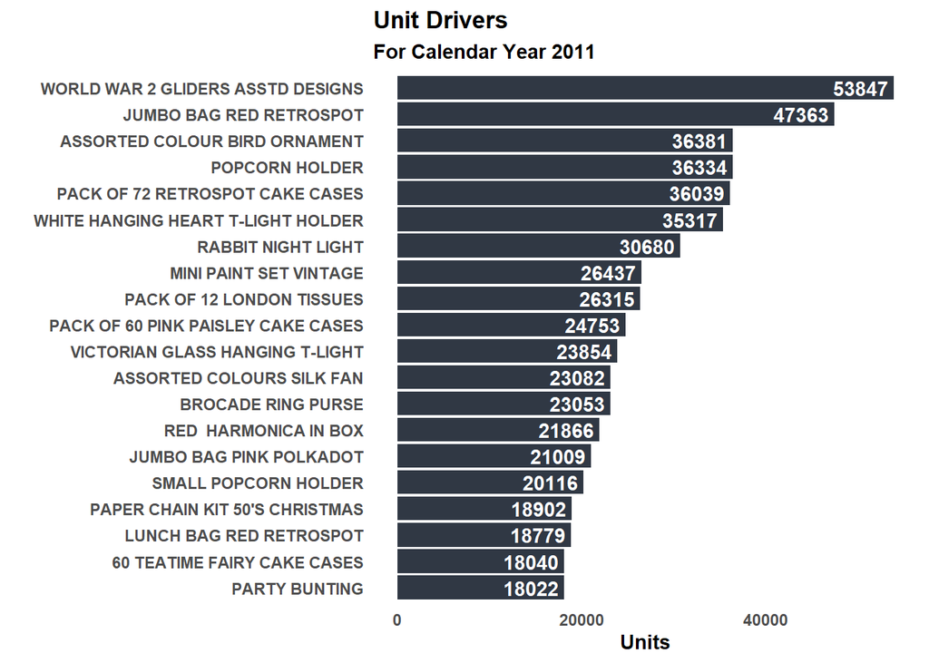

```r
unit_drivers <- sales %>%
  select(description, quantity) %>%
  group_by(description) %>%
  summarise(total_quantity = sum(quantity)) %>%
  filter(total_quantity >3) %>%
  ungroup() %>%
  arrange(desc(total_quantity)) %>%
  head(20)


unit_drivers %>%
  ggplot(aes(fct_reorder(description, total_quantity), total_quantity, label = total_quantity)) +
  geom_col(fill = "#303844")+
  geom_text(hjust = 1.1, color = "white",fontface = "bold")+
  coord_flip()+
  theme_minimal()+
  theme(text = element_text(family = "Nunito Bold", face = "bold"),
          axis.ticks = element_blank(),
          panel.grid = element_blank()
          )+
  labs(
    title = "Unit Drivers",
    subtitle = "For Calendar Year 2011",
    x = "",
    y = "Units"
  ) -> graph_unit_drivers

graph_unit_drivers
```

## Dollar Drivers

Let’s run the same type of analysis and identify our top dollar drivers.

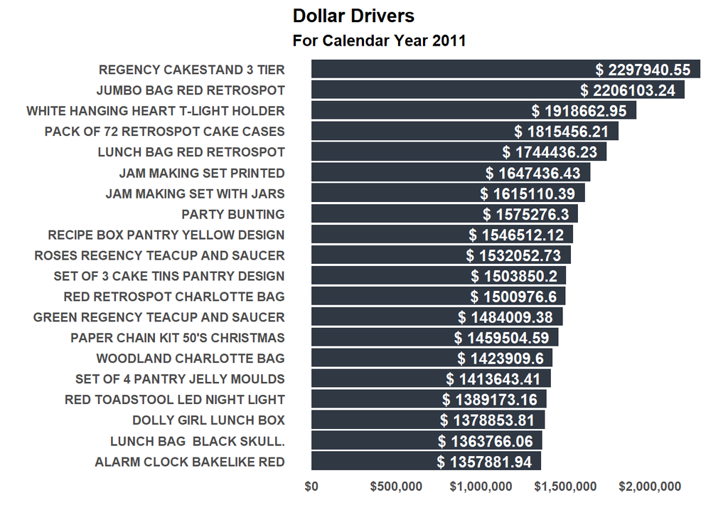

```r
dollar_drivers <- sales %>%
  select(description, invoice_total_value) %>%
  group_by(description) %>%
  summarise(total_dollars = sum(invoice_total_value)) %>%
  ungroup() %>%
  mutate(label_text = paste("$",round(total_dollars, digits = 2)),
         label_text = trimws(label_text))%>%
  arrange(desc(total_dollars))%>%
  head(20)

dollar_drivers %>%
  ggplot(aes(fct_reorder(description, total_dollars), total_dollars, label = label_text)) +
  geom_col(fill = "#303844")+
  geom_text(hjust = 1.1, color = "white",fontface = "bold")+
  scale_y_continuous(labels=scales::dollar_format())+
  coord_flip()+
  theme_minimal()+
  theme(text = element_text(family = "Nunito Bold", face = "bold"),
          axis.ticks = element_blank(),
          panel.grid = element_blank()
          )+
  labs(
    title = "Dollar Drivers",
    subtitle = "For Calendar Year 2011",
    x = "",
    y = ""
  ) -> graph_dollar_drivers

graph_dollar_drivers
```

Looking at the two graphs we can see that a few SKU’s show up in both the dollar drivers and the unit drivers. For instance the *Party Bunting*, and the *Pack of 72 Retrospot Cake Cases*. It is safe to say that these two SKU’s make up an important part of the business.

## Where in the World Are Our Sales?

```r
sales_by_country <- sales %>%
  select(country, invoice_total_value) %>%
  group_by(country) %>%
  summarise(total_sales_by_country = sum(invoice_total_value))


sales_by_country %>%
  arrange(desc(total_sales_by_country)) %>%
  gt() %>%
  fmt_currency(
    # Define the columns to change
    columns = vars(total_sales_by_country),
    # How many decimals to round to
    decimals = 2,
  ) %>%
  # Align the now character column to be right-aligned
  cols_align(
    align = "right",
    columns = vars(total_sales_by_country)) %>%
  cols_label(
    total_sales_by_country = "Total Sales",
    country = "Country"
  )  %>%
  tab_header(
    title = md("**Sales by Country**"),
    subtitle = "2011"
  )
```

**Sales by Country**

| Country | Total Sales |
| --- | --- |
| United Kingdom | $652,672,300.00 |
| Netherlands | $18,093,270.11 |
| Australia | $10,524,587.39 |
| EIRE | $9,958,173.60 |
| Germany | $7,728,452.33 |
| France | $7,332,944.50 |
| Switzerland | $4,163,775.10 |
| Spain | $2,172,299.21 |
| Norway | $1,891,707.24 |
| Portugal | $1,294,880.06 |
| Belgium | $1,179,874.95 |
| Japan | $931,334.20 |
| Israel | $905,426.91 |
| Channel Islands | $858,722.68 |
| Cyprus | $848,770.76 |
| Sweden | $774,996.46 |
| Finland | $735,092.37 |
| Italy | $630,858.70 |
| Singapore | $553,321.72 |
| Hong Kong | $522,479.73 |
| Denmark | $466,853.60 |
| Austria | $307,311.71 |
| Unspecified | $189,661.49 |
| Poland | $168,920.07 |
| Canada | $163,279.88 |
| Greece | $147,157.84 |
| Iceland | $134,181.24 |
| Malta | $87,997.60 |
| Lebanon | $76,224.60 |
| United Arab Emirates | $62,809.68 |
| RSA | $58,133.98 |
| USA | $38,928.34 |
| Brazil | $36,595.20 |
| Lithuania | $32,208.50 |
| European Community | $29,123.05 |
| Czech Republic | $10,779.66 |
| Bahrain | $6,328.20 |
| Saudi Arabia | $1,298.53 |

The vast, vast majority of the yearly sales came from the UK. Considering that this business is based there, that makes sense. Looking at our lowest value countries, We have Saudi Arabia, Bahrain and The Czech Republic. If there is marketing dollars being spent there currently, it may be wise to move it else where.

# Wrap Up

We took a look at our sales data from this anonymized store data set. We look at unit drivers, dollar drivers and which countries produced the most sales. In the future it would be beneficial to examine customer segmentation, perhaps utilizing KNN. I will save that for a future blog post however.